# Funciones

Junio, 2015

## Introducción

La creación de funciones es la principal utilidad de un lenguaje de programación, aún en un lenguaje orientado a la estadística como R. Ahora nos dedicaremos a la comprensión de la estructura y funcionamiento de las funciones, así como a la creación y corrección de las mismas.

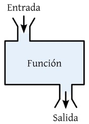

Una **función** es un conjunto de instrucciones que se escribe una vez, pero que puede ejecutarse muchas veces. Las funciones toman **datos de entrada**, usan estos datos para calcular otros valores y retornan un **resultado**.

## Motivación

[figure not shown]

```r
casino <- function(){
      symbol <- c("Diamante", "0", "7", "$")
      sample(symbol, size=3, replace=TRUE, prob=c(0.25, 0.25, 0.25, 0.25))
}

casino()
```

```
#> [1] "Diamante" "Diamante" "$"
```

## Por qué construir funciones ?

El primer motivo, es la **practicidad**. Pues existen situaciones en las que se requiere la ejecución de comandos en un orden específico, o volver a ejecutar una serie de comandos que los vamos a tener que utilizar nuevamente. En casos como estos, puede ahorrarnos tiempo y esfuerzo escribir una función que contenga estos pasos y que podamos utilizar una y otra vez.

Un ejemplo claro de esto es la función `sort`, que ejecuta las instrucciones necesarias para ordenar un vector.

```r
x <- sample(1:15, size=8)  # Generamos un vector en desorden
x
```

```
#> [1] 14  9  1  8  5 15  7  3
```

```r
sort (x)  # la ejecución de 'sort' nos devuelve este vector ordenado.
```

```
#> [1]  1  3  5  7  8  9 14 15
```

Dentro de esta función están las instrucciones necesarias para realizar la tarea, y que se ejecutarán sin necesidad de hacerlo paso a paso.

## Por qué construir funciones ?

El segundo motivo, es la **generalización**. Muchas veces vamos a generar una función para atender a un caso particular, sin embargo, en la medida en que las funciones que escribimos nos resulten útiles, es importante poder pasar de su aplicabilidad a variables que podamos modificar en cada caso.

### Ejemplo:

El problema planteado es el área de un triángulo que presenta 3 cm de base y 4 cm de altura. La forma más sencilla de estimar la misma es, directamente,

```r
4 * 3 / 2
```

```
#> [1] 6
```

Sin embargo, si necesitamos hallar el área de varios triángulos, podemos crear la función `area`, utilizando base y altura como variables.

```r
area <- function(a, b) {
  a * b / 2
}
```

## Estructuras de Control

- Se trata de un conjunto de herramientas que permite manejar de forma mucho más elaborada el flujo de ejecución de nuestros comandos.
- Permiten realizar cosas como repetir líneas, hacer bifurcaciones y mucho más (virtualmente, lo que sea que se nos ocurra).
- Tanto las estructuras de control como el uso de funciones son aspectos fundamentales de la programación, más allá de cuál sea el lenguaje que escojamos para nuestro trabajo.
- En R podemos acceder a la ayuda de las estructuras de control con el comando:

```r
help(Control)
```

Las estructuras de control se clasifican en:

1. **Condicionales:** if, else (e ifelse).
2. **Loops o bucles:** for, while.

## Sentencia IF

La sentencia **IF** realiza una tarea para un determinado caso.

```r
if (condicion){
      tarea
}
```

La condición debe ser una prueba lógica o una expresión que evalúa si es VERDADERO o FALSO. Si se evalúa como verdadero R ejecuta el código que se encuentra entre llaves.

```r
if(num < 0){
      num <- num + 1
}
```

No existe un límite en la cantidad de código que puede ejecutarse entre llaves.

## Sentencia ELSE

La sentencia **ELSE** trabaja como complemento de la sentencia **IF**, por tanto, ejecuta una tarea cuando la condición es FALSA.

```r
if (condicion) {
      tarea 1
} else {
      tarea 2
}
```

R internamente evalúa si la condición es VERDADERA y ejecuta la tarea 1, en caso contrario ejecuta la tarea 2.

```r
a <- -2
if (a>=0) {
      print("El número es positivo")
} else {
      print("El número es negativo")
}
```

## Sentencia FOR

La sentencia FOR nos permite repetir una acción un número determinado de veces.

```r
for(iteraciones){
      tarea
}
```

Para escribir valores en medio de un bucle es necesario utilizar `print()`.

```r
for(i in 1:4) {
      print(i)
}
```

Lo cual es equivalente a:

```r
i <- 1
print(i)
i <- 2
print(i)
i <- 3
print(i)
i <- 4
print(i)
```

## Sentencia FOR

Una operación común dentro del análisis de datos es la suma de filas/columnas, a continuación un ejercicio al respecto:

```r
m <- matrix(rpois(12, 8), 4, 3) # Una matriz de 4x3
m
```

```
#>      [,1] [,2] [,3]
#> [1,]    5    5    4
#> [2,]    4    9   15
#> [3,]    7    9    9
#> [4,]   10   18    9
```

```r
s <- numeric(4) # Un vector de longitud 4, con sus valores = 0
# Loop:
for (i in 1:4){
      s[i] <- sum(m[i,])
}
s
```

```
#> [1] 14 28 25 37
```

## Sentencia FOR

Lazos con el mismo comportamiento:

```r
x <- c("a", "b", "c", "d")

for(i in 1:4) {
        print(x[i])
}

for(i in seq_along(x)) {
        print(x[i])
}

for(letter in x) {
        print(letter)
}

for(i in 1:4) print(x[i])
```

## Loops Anidados

Nada impide que adentro de un for se escriba otro loop. Esto es lo que llamamos un **loop anidado**. Las reglas que siguen son las mismas que antes, pero hay que tener la precaución de utilizar diferentes nombres para las variables de iteración. En el siguiente ejemplo se usan i y j como variables:

```r
s <- numeric(1)
m <- matrix(rpois(4, 8), 2, 2) # Una matriz de 2x2
m
```

```
#>      [,1] [,2]
#> [1,]    6   18
#> [2,]    8   11
```

```r
for (i in 1:nrow(m)) {
  for (j in 1:ncol(m)) {
    s <- s + m[i, j]
  }
}
s
```

```
#> [1] 43
```

## Ejercicios sobre Estructuras de Control

1. Escriba un algoritmo que permita evaluar la función en todo su dominio.

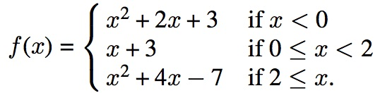

2. Escriba un algoritmo que almacene la siguiente suma: \[\sum_{i=10}^{100} (i^3 + 4i^2)\]
3. Escriba un algoritmo usando una instrucción **for** que calcule el promedio móvil de orden 2 de un vector \(x=(x_1, x_2, \ldots, x_n)\). El promedio móvil de orden 2 es el vector de longitud \(n-1\) cuya i-ésima componente es \((x_i + x_{i+1})/2\).

## Estructura

La estructura de una función es la siguiente:

```r
nombre_funcion <- function(argumento_1, argumento_2, ... ){
      sentencia_1
      sentencia_2
      .
      .
      sentencia_n
      return("objecto_retornarse")
}
```

El comando `function()` tiene como tarea crear funciones a partir de ciertos argumentos que son proporcionados por el usuario.

```r
logn <- function(x, n){
      return(log(x, base = n))
}

logn(8, 2) # Logaritmo de 8 en base 2
```

```
#> [1] 3
```

## Partes de una función

- **Cuerpo:** Conjunto de sentencias o código principal de la función.

```r
body(logn)
```

```
#> {
#>     return(log(x, base = n))
#> }
```

- **Argumentos:** Listado de valores que controlan la llamada de la función.

```r
formals(logn)
```

[output not shown]

- **Ambiente:** Lugar de la memoria en la cual se ubican las variables de la función.

```r
environment(logn)
```

```
#> <environment: R_GlobalEnv>
```

## Argumentos

No existe un límite en la cantidad de argumentos que una *función* puede recibir.

```r
hipotenusa <- function(x,y){
      return(sqrt(x^2+y^2))
}

hipotenusa(3,4)
```

```
#> [1] 5
```

Dimensionemos el cálculo de la hipotenusa a 4 dimensiones:

```r
hipotenusa_4d <- function(w,x,y,z){
      return(sqrt(w^2+x^2+y^2+z^2))
}

hipotenusa_4d(2,3,4,5)
```

```
#> [1] 7.348469
```

## Argumentos por default

Existen situaciones en las cuales no es necesario que el usuario ingrese uno o varios argumentos para que la función pueda ejecutarse.

```r
hip <- function(x=3, y=4){
      return(sqrt(x^2+y^2))
}
```

```r
hip()
```

```
#> [1] 5
```

```r
hip(x=6)
```

```
#> [1] 7.211103
```

```r
hip(y=8)
```

```
#> [1] 8.544004
```

## Lexical Scoping

Consideremos la siguiente función:

```r
f <- function(x, y) {
        return(x^2 + y / z)
}
```

La función tiene 2 argumentos x, y, además observamos que el cuerpo de la función existe la variable z (**variable libre**). Las reglas de asignación de valores en R nos permiten determinar el valor asociado z.

```r
f(3, 6)
```

```
#> Error in f(3, 6): object 'z' not found
```

```r
z <- 2
f(3, 6)
```

```
#> [1] 12
```

## Lexical Scoping

Considere la siguiente función:

```r
y <- 10

f <- function(x) {
        y <- 2
        y^2 + g(x)
}

g <- function(x) {
        x*y
}
```

Cuál es el valor de f(3) ?

```r
f(3)
```

```
#> [1] 34
```

## Lexical Scoping

Cuál es el valor de g(2) ?

```r
a <- 2
b <- 1
f <- function(x){
      a*x+b
}

g <- function(x){
      a <- 1
      b <- 2
      f(x)
}
```

```r
g(2)
```

```
#> [1] 5
```

## Ejemplo: Curva Logística

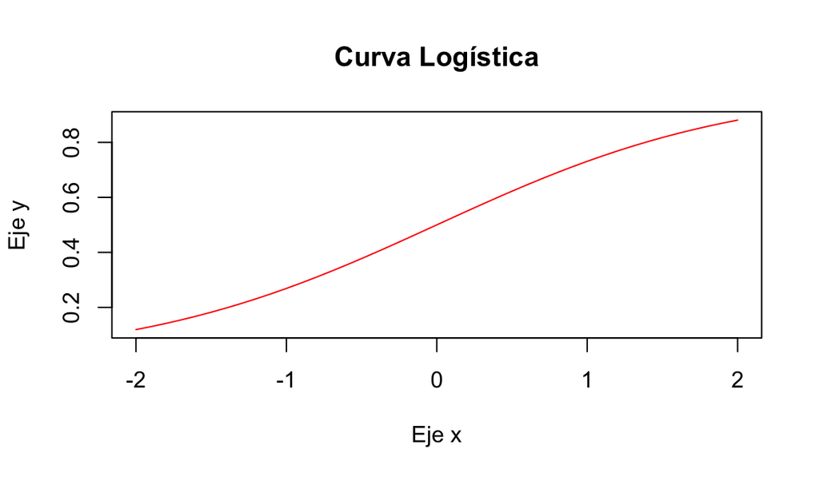

```r
logi <- function(ini, fin, color="red") {
  x <- seq(ini, fin, by=0.1)
  y <- exp(x) / (1 + exp(x))
  plot(y ~ x, type='l', col=color, main="Curva Logística", xlab="Eje x", ylab="Eje y")
}
logi(ini=-2, fin=2)
```

## Simulación: Pasajeros - Paradas

Ahora generaremos un código para simular la cantidad de pasajeros en un bus urbano.

[figure not shown]

El criterio es el siguiente: el bus recorre 25 paradas, empezando el trayecto sin pasajeros. En cada parada se subirán de 0 a 8 personas, pero debido a que existe un máximo estipulado de personas, a partir del momento en que se alcanza el total de 44 pasajeros el vehículo deja de parar. Todos los pasajeros se movilizan hasta la parada final.

## Solución: Pasajeros - Paradas

```r
paradas <- 25
pasajeros <- 0
registro <- numeric(25)
for (i in 1:paradas) {
      pasajeros <- pasajeros + sample(0:8, size=1)
      if (pasajeros >= 44) {
            registro[i:paradas] <- 44
            cat('Bus lleno!\n')
            break
      } else {
            registro[i] <- pasajeros
            cat('Parada', i, 'hay', pasajeros, 'pasajeros\n')
      }
}
plot(registro, xlab='Parada', ylab='No. de pasajeros', main="Pasajeros", col="blue")
```

## Resultados Simulación

```
#> Parada 1 hay 6 pasajeros
#> Parada 2 hay 13 pasajeros
#> Parada 3 hay 19 pasajeros
#> Parada 4 hay 26 pasajeros
#> Parada 5 hay 30 pasajeros
#> Parada 6 hay 31 pasajeros
#> Parada 7 hay 33 pasajeros
#> Parada 8 hay 37 pasajeros
#> Parada 9 hay 43 pasajeros
#> Bus lleno!
```

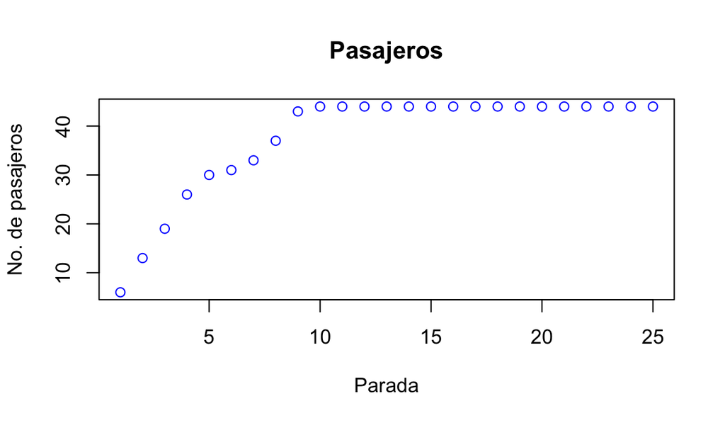

## Simulación: Pasajeros - Paradas

1. Modifique el código para crear una función con nombre **simubus** que ejecute la misma simulación, en la que el número de paradas **(p)** y capacidad máxima **(m)** del bus sean los argumentos de la misma.
2. Hacer una variante del código en la que además de subir personas, a partir de la parada 10 se bajen entre 0 y 4 pasajeros por parada.

## R Analytic Flow

R Analytic Flow es una interfaz gráfica desarrollada por Ryota Suzuki, la cual facilita el análisis de datos a través de diagramas de flujo. El software se encuentra bajo licencia BSD & GPL, por lo cual puede obtenerse de forma gratuita a través de la página web de Ef-prime, Inc. http://www.ef-prime.com para las plataformas: Windows, Mac OS X y Linux.

[figure not shown]

## Preguntas

[figure not shown]